**Deep Learning for Mechanical Engineering**  
**Anomaly Detection**

Instructor: Prof. Seungchul Lee  
http://iai.postech.ac.kr/  
Industrial AI Lab at POSTECH

# Problem 1

In this problem, we are going to perform anomaly detection using 1D Convolution layers

- Two datasets are given. The first dataset (df_normal) does not contain anomalous data while the second dataset (df_anomaly) contains anomalous data. The main objective of this problem is to find the indices of anomalous data within the second dataset. We will use the concept of reconstruction error discussed in the class.

(0) Import libraries and load data ([link](https://www.dropbox.com/s/4p409nunl3eloxh/Anomaly_Problem1_Dataset.zip?dl=1))

```python
import numpy as np
import pandas as pd
import tensorflow as tf
from matplotlib import pyplot as plt
from sklearn.model_selection import train_test_split
```

```python
df_normal = pd.read_csv('./data_files/df_normal.csv',
                        parse_dates = True,
                        index_col = "timestamp")

df_anomaly = pd.read_csv('./data_files/df_anomaly.csv',
                         parse_dates = True,
                         index_col = "timestamp")
```

```python
df_normal
```

| timestamp | value |
| --- | --- |
| 2014-04-01 00:00:00 | 18.324919 |
| 2014-04-01 00:05:00 | 21.970327 |
| 2014-04-01 00:10:00 | 18.624806 |
| 2014-04-01 00:15:00 | 21.953684 |
| 2014-04-01 00:20:00 | 21.909120 |
| ... | ... |
| 2014-04-14 23:35:00 | 20.211195 |
| 2014-04-14 23:40:00 | 20.531041 |
| 2014-04-14 23:45:00 | 19.032127 |
| 2014-04-14 23:50:00 | 21.798801 |
| 2014-04-14 23:55:00 | 18.682620 |

4032 rows × 1 columns

```python
df_anomaly
```

| timestamp | value |
| --- | --- |
| 2014-04-01 00:00:00 | 19.761252 |
| 2014-04-01 00:05:00 | 20.500833 |
| 2014-04-01 00:10:00 | 19.961641 |
| 2014-04-01 00:15:00 | 21.490266 |
| 2014-04-01 00:20:00 | 20.187739 |
| ... | ... |
| 2014-04-14 23:35:00 | 18.074649 |
| 2014-04-14 23:40:00 | 21.002014 |
| 2014-04-14 23:45:00 | 20.566713 |
| 2014-04-14 23:50:00 | 18.254193 |
| 2014-04-14 23:55:00 | 21.863147 |

4032 rows × 1 columns

(1) Normalize the first dataset (df_normal) with the standard scaler (Z-score)

```python
normal_mean = df_normal.mean()
normal_std = df_normal.std()
normal_value = (df_normal - normal_mean) / normal_std

print("Number of samples:", len(normal_value))
normal_value
```

```
Number of samples: 4032
```

| timestamp | value |
| --- | --- |
| 2014-04-01 00:00:00 | -0.858829 |
| 2014-04-01 00:05:00 | -0.728993 |
| 2014-04-01 00:10:00 | -0.848148 |
| 2014-04-01 00:15:00 | -0.729586 |
| 2014-04-01 00:20:00 | -0.731173 |
| ... | ... |
| 2014-04-14 23:35:00 | -0.791647 |
| 2014-04-14 23:40:00 | -0.780255 |
| 2014-04-14 23:45:00 | -0.833640 |
| 2014-04-14 23:50:00 | -0.735102 |
| 2014-04-14 23:55:00 | -0.846089 |

4032 rows × 1 columns

(2) Generate multiple data from the df_normal dataset

- Each data should have 288 time steps
- You can generate multiple data by using the sliding window concept
- Split generated multiple data into train and test set (test_size is 0.2)
- ex) Original dataset: 1, 2, 3, 4, 5, 6  
  Let's make multiple data by grouping three digits for each data  
  Result: (1,2,3), (2,3,4), (3,4,5), (4,5,6)

```python
TIME_STEPS = 288

def create_sequences(values, time_steps = TIME_STEPS):
    output = []
    for i in range(len(values) - time_steps + 1 ):
        output.append(values[i: (i + time_steps)])
    return np.stack(output)

x_data = create_sequences(normal_value.values)

x_train, x_test = train_test_split(x_data, test_size = 0.2, random_state = 42)
print("Training input shape: ", x_train.shape)
```

```
Training input shape:  (2996, 288, 1)
```

(3) Define the model

- It is 1D version of Convolutional Autoencoder

```python
model = tf.keras.models.Sequential([
        tf.keras.layers.Input(shape = (x_train.shape[1], x_train.shape[2])),

        tf.keras.layers.Conv1D(filters = 32,
                               kernel_size = 7,
                               padding = "same",
                               strides = 2,
                               activation = "relu"),

        tf.keras.layers.Dropout(rate = 0.2),

        tf.keras.layers.Conv1D(filters = 16,
                               kernel_size = 7,
                               padding = "same",
                               strides = 2,
                               activation = "relu"),

        tf.keras.layers.Conv1DTranspose(filters = 16,
                                        kernel_size = 7,
                                        padding = "same",
                                        strides = 2,
                                        activation = "relu"),

        tf.keras.layers.Dropout(rate = 0.2),

        tf.keras.layers.Conv1DTranspose(filters = 32,
                                        kernel_size = 7,
                                        padding = "same",
                                        strides = 2,
                                        activation = "relu"),

        tf.keras.layers.Conv1DTranspose(filters = 1,
                                        kernel_size = 7,
                                        padding = "same"),
])

model.compile(optimizer = tf.keras.optimizers.Adam(learning_rate = 0.001),
              loss = "mse")

model.summary()
```

```
Model: "sequential"
_________________________________________________________________
Layer (type)                 Output Shape              Param #
=================================================================
conv1d (Conv1D)              (None, 144, 32)           256
_________________________________________________________________
dropout (Dropout)            (None, 144, 32)           0
_________________________________________________________________
conv1d_1 (Conv1D)            (None, 72, 16)            3600
_________________________________________________________________
conv1d_transpose (Conv1DTran (None, 144, 16)           1808
_________________________________________________________________
dropout_1 (Dropout)          (None, 144, 16)           0
_________________________________________________________________
conv1d_transpose_1 (Conv1DTr (None, 288, 32)           3616
_________________________________________________________________
conv1d_transpose_2 (Conv1DTr (None, 288, 1)            225
=================================================================
Total params: 9,505
Trainable params: 9,505
Non-trainable params: 0
_________________________________________________________________
```

(4) Train the model

- optimizer: adam
- loss: mse
- epochs: 25
- batch size: 128
- validation split: 0.1

```python
history = model.fit(x_train,
                    x_train,
                    epochs = 25,
                    batch_size = 128,
                    validation_split = 0.1,
                    callbacks = [tf.keras.callbacks.EarlyStopping(monitor = "val_loss", patience = 5, mode = "min")])
```

(5) Plot the training loss and validation loss

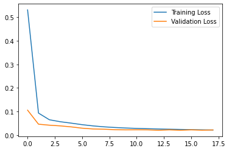

```python
plt.plot(history.history["loss"], label = "Training Loss")
plt.plot(history.history["val_loss"], label = "Validation Loss")
plt.legend()
plt.show()
```

(6) Calculate reconstruction error of entire test dataset and set the threshold

- Reconstruction error can be considered as MAE between the input and the output
- Set maximum value of the reconstruction error as a threshold for detecting anomalous data
- Plot the test MAE loss distribution

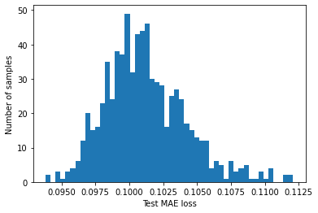

```
Reconstruction error threshold:  0.11208951202206184
```

```python
x_test_pred = model.predict(x_test)

test_mae_loss = np.mean(np.abs(x_test_pred - x_test), axis = 1)

plt.hist(test_mae_loss, bins = 50)
plt.xlabel("Test MAE loss")
plt.ylabel("Number of samples")
plt.show()

threshold = np.max(test_mae_loss)
print("Reconstruction error threshold: ", threshold)
```

(7) Repeat the step (1) and (2) for the second (df_anomaly) dataset

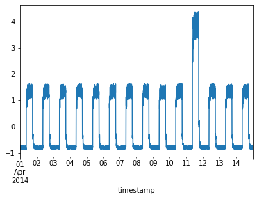

```
Anomaly data input shape:  (3745, 288, 1)
```

```python
anomaly_value = (df_anomaly - normal_mean) / normal_std
anomaly_value.plot(legend = False)
plt.show()

x_anomaly = create_sequences(anomaly_value.values)
print("Anomaly data input shape: ", x_anomaly.shape)
```

(8) Calculate the reconstruction error of entire df_anomaly data generated in step (7) and plot the distribution

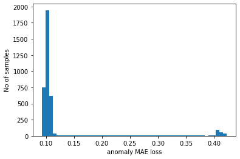

```python
x_anomaly_pred = model.predict(x_anomaly)
anomaly_mae_loss = np.mean(np.abs(x_anomaly_pred - x_anomaly), axis = 1)
anomaly_mae_loss = anomaly_mae_loss.reshape((-1))

plt.hist(anomaly_mae_loss, bins = 50)
plt.xlabel("anomaly MAE loss")
plt.ylabel("No of samples")
plt.show()
```

(9) Find the number of data in df_anomaly dataset that are anomalous and print their indices

- Use the threshold defined beforehand

```python
anomalies = anomaly_mae_loss > threshold
print("Number of anomaly samples: ", np.sum(anomalies))
print("Indices of anomaly samples: ", np.where(anomalies))
```

```
Number of anomaly samples:  431
Indices of anomaly samples:  (array([ 212,  214,  786,  787,  788,  789,  790,  791,  794,  795, 1651,
       1652, 1653, 1654, 1655, 1657, 1658, 1659, 1660, 1661, 1662, 1833,
       1834, 2516, 2517, 2518, 2519, 2521, 2522, 2523, 2524, 2525, 2526,
       2696, 2697, 2698, 2701, 2702, 2703, 2704, 2705, 2706, 2707, 2708,
       2709, 2710, 2711, 2712, 2713, 2714, 2715, 2716, 2717, 2718, 2719,
       2720, 2721, 2722, 2723, 2724, 2725, 2726, 2727, 2728, 2729, 2730,
       2731, 2732, 2733, 2734, 2735, 2736, 2737, 2738, 2739, 2740, 2741,
       2742, 2743, 2744, 2745, 2746, 2747, 2748, 2749, 2750, 2751, 2752,
       2753, 2754, 2755, 2756, 2757, 2758, 2759, 2760, 2761, 2762, 2763,
       2764, 2765, 2766, 2767, 2768, 2769, 2770, 2771, 2772, 2773, 2774,
       2775, 2776, 2777, 2778, 2779, 2780, 2781, 2782, 2783, 2784, 2785,
       2786, 2787, 2788, 2789, 2790, 2791, 2792, 2793, 2794, 2795, 2796,
       2797, 2798, 2799, 2800, 2801, 2802, 2803, 2804, 2805, 2806, 2807,
       2808, 2809, 2810, 2811, 2812, 2813, 2814, 2815, 2816, 2817, 2818,
```

[output cut: 26 more lines]

(10) Among data indices from step (9) we will define data i as an anomaly if samples with indices of [(i - timesteps + 1) to (i)] are anomalies

- Create new set of indices of anomalous data that satisfies above criterion

```python
anomalous_data_indices = []
for data_idx in range(TIME_STEPS - 1, len(anomaly_value) - TIME_STEPS + 1):
    if np.all(anomalies[data_idx - TIME_STEPS + 1 : data_idx]):
        anomalous_data_indices.append(data_idx)
```

(11) Now, you have indices of anomalous data! Plot entire df_anomaly dataset and mark anomalous data among the dataset with red

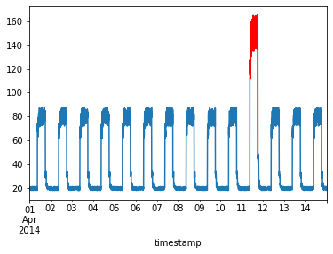

```python
df_subset = df_anomaly.iloc[anomalous_data_indices]
fig, ax = plt.subplots()
df_anomaly.plot(legend = False, ax = ax)
df_subset.plot(legend = False, ax = ax, color = "r")
plt.show()
```

# Problem 2

In this problem, we are going to perform anomaly detection using LSTM layers

- The dataset given below is composed of data from four bearing sensors on a single bearing. In other words, there were four sensors attached to the bearing. We have collected the data from 2004-02-12 to 2004-02-19. We noticed that some time after 2004-02-15, the bearing started to malfunction. The main objective of this problem is to find exact date and time when the bearing started to malfunction. We will use the concept of reconstruction error discussed in the class.

(0) Import libraries and load the data which you can download it from this [link](https://www.dropbox.com/s/edrnoqdtepsdnfq/Anomaly_Problem2_Dataset.csv?dl=1)

- We have solid belief that the bearing did not malfunction until 2004-02-15 12:52:39
- Set data collected after 2004-02-15 12:52:39 as test dataset to find the exact date and time when the malfunction (anomaly) happened
- Use data collected before 2004-02-15 12:52:39 as train dataset to perform anomaly detection

```python
import os
import pandas as pd
import numpy as np
from sklearn.preprocessing import MinMaxScaler
import matplotlib.pyplot as plt
import tensorflow as tf
```

```python
# You might need to change the data directory below
merged_data = pd.read_csv('./data_files/Anomaly_Problem2_Dataset.csv')
merged_data.set_index('Unnamed: 0', inplace = True)
merged_data
```

| Unnamed: 0 | Bearing 1 | Bearing 2 | Bearing 3 | Bearing 4 |
| --- | --- | --- | --- | --- |
| 2004-02-12 10:52:39 | 0.060236 | 0.074227 | 0.083926 | 0.044443 |
| 2004-02-12 11:02:39 | 0.061455 | 0.073844 | 0.084457 | 0.045081 |
| 2004-02-12 11:12:39 | 0.061361 | 0.075609 | 0.082837 | 0.045118 |
| 2004-02-12 11:22:39 | 0.061665 | 0.073279 | 0.084879 | 0.044172 |
| 2004-02-12 11:32:39 | 0.061944 | 0.074593 | 0.082626 | 0.044659 |
| ... | ... | ... | ... | ... |
| 2004-02-19 05:42:39 | 0.453335 | 0.161016 | 0.137440 | 0.119047 |
| 2004-02-19 05:52:39 | 0.337583 | 0.132400 | 0.144992 | 0.092125 |
| 2004-02-19 06:02:39 | 0.351111 | 0.152266 | 0.151299 | 0.100817 |
| 2004-02-19 06:12:39 | 0.001857 | 0.003732 | 0.003656 | 0.001786 |
| 2004-02-19 06:22:39 | 0.001168 | 0.000767 | 0.000716 | 0.001699 |

982 rows × 4 columns

```python
# Bearing sensor data before 2004-02-15 12:52:39 = training data
# Bearing sensor data after 2004-02-15 12:52:39 = test data
train = merged_data['2004-02-12 10:52:39': '2004-02-15 12:52:39']
test = merged_data['2004-02-15 12:52:39':]
print("Training dataset shape:", train.shape)
print("Test dataset shape:", test.shape)
```

```
Training dataset shape: (445, 4)
Test dataset shape: (538, 4)
```

(1) Plot training and test dataset separately

- There were four sensors attached to the bearing and the data from each sensor is named 'Bearing 1', 'Bearing 2', 'Bearing 3', and 'Bearing 4'

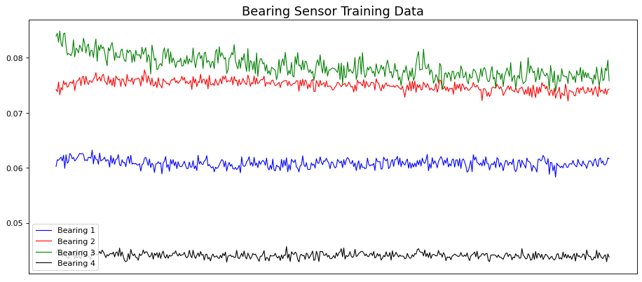

```python
fig, ax = plt.subplots(figsize = (14, 6), dpi = 80)
ax.plot(train['Bearing 1'], label = 'Bearing 1', color = 'blue', animated = True, linewidth = 1)
ax.plot(train['Bearing 2'], label = 'Bearing 2', color = 'red', animated = True, linewidth = 1)
ax.plot(train['Bearing 3'], label = 'Bearing 3', color = 'green', animated = True, linewidth = 1)
ax.plot(train['Bearing 4'], label = 'Bearing 4', color ='black', animated = True, linewidth = 1)
plt.legend(loc = 'lower left')
ax.set_title('Bearing Sensor Training Data', fontsize = 16)
ax.axes.get_xaxis().set_visible(False)
plt.show()
```

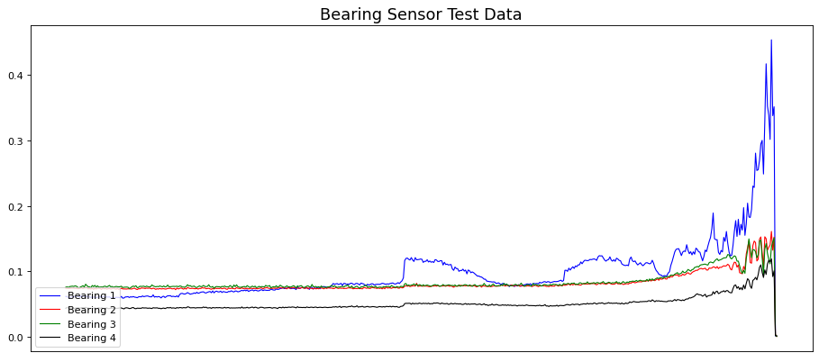

```python
fig, ax = plt.subplots(figsize = (14, 6), dpi = 80)
ax.plot(test['Bearing 1'], label = 'Bearing 1', color = 'blue', animated = True, linewidth = 1)
ax.plot(test['Bearing 2'], label = 'Bearing 2', color = 'red', animated = True, linewidth = 1)
ax.plot(test['Bearing 3'], label = 'Bearing 3', color = 'green', animated = True, linewidth = 1)
ax.plot(test['Bearing 4'], label = 'Bearing 4', color = 'black', animated = True, linewidth = 1)
plt.legend(loc = 'lower left')
ax.set_title('Bearing Sensor Test Data', fontsize = 16)
ax.axes.get_xaxis().set_visible(False)
plt.show()
```

(2) We will transform the data from the time domain to the frequency domain using Fast Fourier Transform (FFT)

- Code for FFT is given below
- Plot the training and test dataset in the frequency domain

```python
train_fft = np.fft.fft(train)
test_fft = np.fft.fft(test)
```

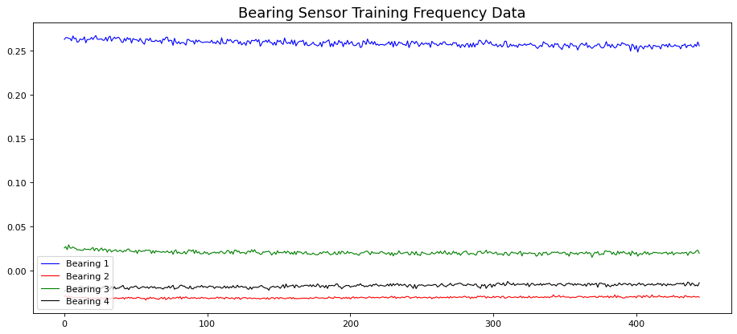

```python
fig, ax = plt.subplots(figsize = (14, 6), dpi = 80)
ax.plot(train_fft[:,0].real, label = 'Bearing 1', color = 'blue', animated = True, linewidth = 1)
ax.plot(train_fft[:,1].imag, label = 'Bearing 2', color = 'red', animated = True, linewidth = 1)
ax.plot(train_fft[:,2].real, label = 'Bearing 3', color = 'green', animated = True, linewidth = 1)
ax.plot(train_fft[:,3].real, label = 'Bearing 4', color = 'black', animated = True, linewidth = 1)
plt.legend(loc = 'lower left')
ax.set_title('Bearing Sensor Training Frequency Data', fontsize = 16)
plt.show()
```

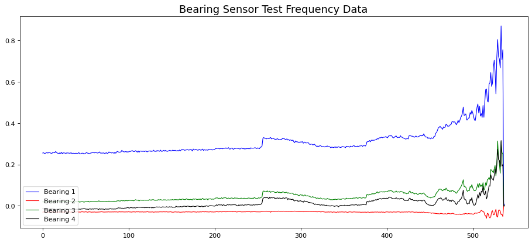

```python
fig, ax = plt.subplots(figsize = (14, 6), dpi = 80)
ax.plot(test_fft[:,0].real, label = 'Bearing 1', color = 'blue', animated = True, linewidth = 1)
ax.plot(test_fft[:,1].imag, label = 'Bearing 2', color = 'red', animated = True, linewidth = 1)
ax.plot(test_fft[:,2].real, label = 'Bearing 3', color = 'green', animated = True, linewidth = 1)
ax.plot(test_fft[:,3].real, label = 'Bearing 4', color = 'black', animated = True, linewidth = 1)
plt.legend(loc = 'lower left')
ax.set_title('Bearing Sensor Test Frequency Data', fontsize = 16)
plt.show()
```

(3) Normalize the data with MinMaxScaler and reshape the input data for LSTM layers

```python
scaler = MinMaxScaler()
X_train = scaler.fit_transform(train)
X_test = scaler.transform(test)
scaler_filename = "scaler_data"
```

```python
X_train = X_train.reshape(X_train.shape[0], 1, X_train.shape[1])
print("Training data shape:", X_train.shape)
X_test = X_test.reshape(X_test.shape[0], 1, X_test.shape[1])
print("Test data shape:", X_test.shape)
```

```
Training data shape: (445, 1, 4)
Test data shape: (538, 1, 4)
```

(4) Define the model

```python
def autoencoder_model(X):

    L1 = tf.keras.layers.LSTM(16,
                              input_shape = (X.shape[1], X.shape[2]),
                              activation = 'relu',
                              return_sequences = True)

    L2 = tf.keras.layers.LSTM(4,
                              activation = 'relu',
                              return_sequences = False)

    L3 = tf.keras.layers.RepeatVector(X.shape[1])

    L4 = tf.keras.layers.LSTM(4,
                              activation = 'relu',
                              return_sequences = True)

    L5 = tf.keras.layers.LSTM(16,
                              activation = 'relu',
                              return_sequences = True)

    output = tf.keras.layers.TimeDistributed(tf.keras.layers.Dense(X.shape[2]))

    model = tf.keras.Sequential([L1, L2, L3, L4, L5, output])

    return model
```

```python
model = autoencoder_model(X_train)
model.compile(optimizer = 'adam', loss = 'mae')
model.summary()
```

```
Model: "sequential_1"
_________________________________________________________________
Layer (type)                 Output Shape              Param #
=================================================================
lstm (LSTM)                  (None, 1, 16)             1344
_________________________________________________________________
lstm_1 (LSTM)                (None, 4)                 336
_________________________________________________________________
repeat_vector (RepeatVector) (None, 1, 4)              0
_________________________________________________________________
lstm_2 (LSTM)                (None, 1, 4)              144
_________________________________________________________________
lstm_3 (LSTM)                (None, 1, 16)             1344
_________________________________________________________________
time_distributed (TimeDistri (None, 1, 4)              68
=================================================================
Total params: 3,236
Trainable params: 3,236
Non-trainable params: 0
_________________________________________________________________
```

(5) Train the model

- optimizer: adam
- loss: mae
- epochs: 100
- batch_size: 10
- validation_split: 0.05

```python
nb_epochs = 100
batch_size = 10
history = model.fit(X_train,
                    X_train,
                    epochs = nb_epochs,
                    batch_size = batch_size,
                    validation_split = 0.05).history
```

(6) Plot the training and validation loss curve

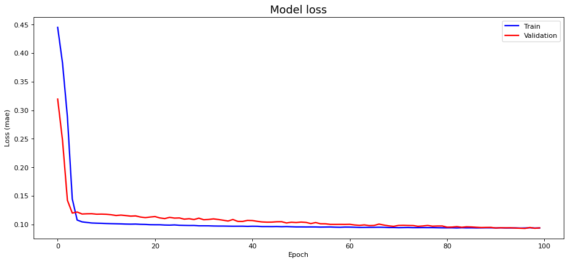

```python
fig, ax = plt.subplots(figsize = (14, 6), dpi = 80)
ax.plot(history['loss'], 'b', label = 'Train', linewidth = 2)
ax.plot(history['val_loss'], 'r', label = 'Validation', linewidth = 2)
ax.set_title('Model loss', fontsize = 16)
ax.set_ylabel('Loss (mae)')
ax.set_xlabel('Epoch')
ax.legend(loc = 'upper right')
plt.show()
```

(7) Calculate reconstruction error of entire training dataset

- Reconstruction error can be considered as MAE between the input and the output of the model
- Plot the loss (reconstruction error) distribution of training dataset

```
(0.0, 0.5)
```

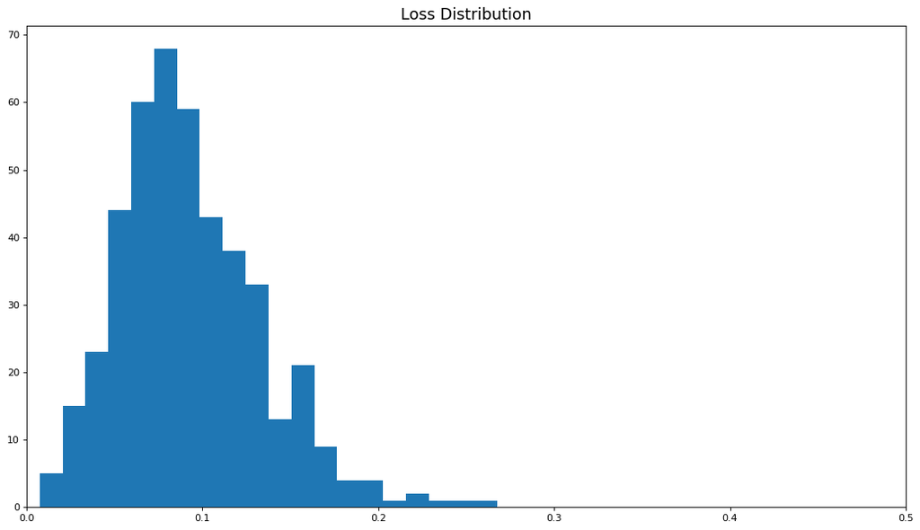

```python
X_pred = model.predict(X_train)
X_pred = X_pred.reshape(X_pred.shape[0], X_pred.shape[2])
X_pred = pd.DataFrame(X_pred, columns = train.columns)
X_pred.index = train.index

scored = pd.DataFrame(index = train.index)
Xtrain = X_train.reshape(X_train.shape[0], X_train.shape[2])
scored['Loss_mae'] = np.mean(np.abs(X_pred - Xtrain), axis = 1)

plt.figure(figsize = (16,9), dpi = 80)
plt.title('Loss Distribution', fontsize = 16)
plt.hist(scored['Loss_mae'], bins = 20)
plt.xlim([0.0,.5])
```

(8) Calculate the reconstruction error of entire test dataset

- Threshold value: 0.275
- Create new dataframe which has the same column value (Year-Month-Date-Time) with the test dataset but contains the reconstruction error, threshold value, and True/False decision regarding malfunction (anomaly) as its row

```python
X_pred = model.predict(X_test)
X_pred = X_pred.reshape(X_pred.shape[0], X_pred.shape[2])
X_pred = pd.DataFrame(X_pred, columns = test.columns)
X_pred.index = test.index

scored = pd.DataFrame(index = test.index)
Xtest = X_test.reshape(X_test.shape[0], X_test.shape[2])
scored['Loss_mae'] = np.mean(np.abs(X_pred - Xtest), axis = 1)
scored['Threshold'] = 0.275
scored['Anomaly'] = scored['Loss_mae'] > scored['Threshold']
scored.head()
```

| Unnamed: 0 | Loss_mae | Threshold | Anomaly |
| --- | --- | --- | --- |
| 2004-02-15 12:52:39 | 0.089779 | 0.275 | False |
| 2004-02-15 13:02:39 | 0.177426 | 0.275 | False |
| 2004-02-15 13:12:39 | 0.062691 | 0.275 | False |
| 2004-02-15 13:22:39 | 0.050215 | 0.275 | False |
| 2004-02-15 13:32:39 | 0.044476 | 0.275 | False |

(9) Plot the new dataframe generated in the step (8)

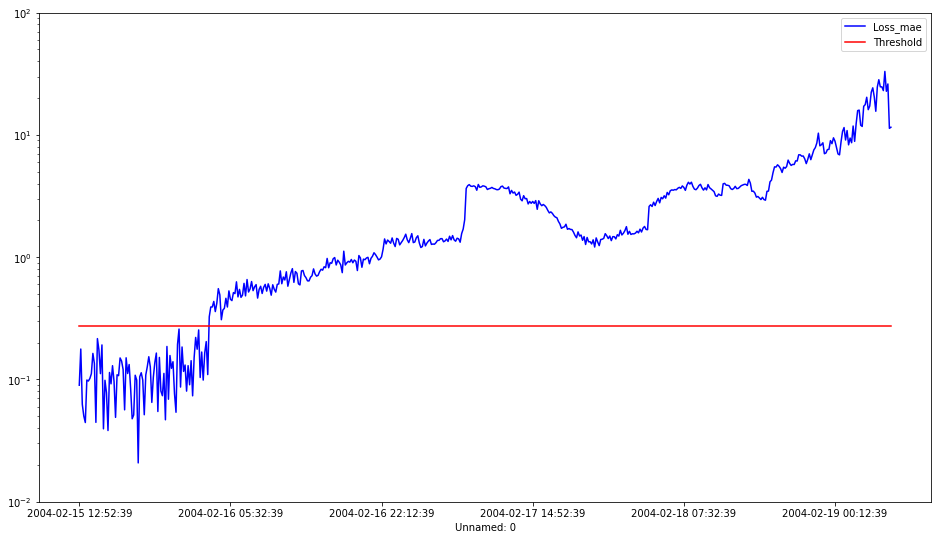

```python
scored.plot(logy = True,  figsize = (16, 9), ylim = [1e-2, 1e2], color = ['blue', 'red'])
```